# Análise Exploratória de Dados

Pet Love - Talents Data Case

Matheus Miranda Brandão

## Imports

```python
import numpy as np
import datetime
import pandas as pd
import matplotlib.pyplot as plt
import seaborn as sns

sns.set(style='darkgrid')
sns.set_theme(style="ticks", rc={"axes.spines.right": False, "axes.spines.top": False})
PALETTE = 'mako'
```

## Observação inicial dos dados

```python
df = pd.read_pickle('../datasets/processed/data-test-analytics.pkl')
df.head()
```

|  | created_at | updated_at | deleted_at | birth_date | status | version | city | state | neighborhood | last_date_purchase | average_ticket | items_quantity | all_revenue | all_orders | recency | marketing_source |
| --- | --- | --- | --- | --- | --- | --- | --- | --- | --- | --- | --- | --- | --- | --- | --- | --- |
| 0 | 2017-08-15 07:05:00 | 2021-01-14 11:23:00 | NaT | 1974-07-10 | active | 2.31.7 | Peixoto da Praia | AM | Aparecida 7ª Seção | 2021-01-14 11:23:00 | 151.142944 | 10 | 906.857666 | 6 | 35 | crm |
| 1 | 2019-12-31 21:53:00 | 2021-01-08 11:23:00 | NaT | 1940-07-06 | paused | 3.30.12 | Fernandes | RR | Santa Isabel | 2021-01-08 11:23:00 | 236.991791 | 4 | 236.991791 | 1 | 41 | organic_search |
| 2 | 2019-03-07 23:46:00 | 2021-01-07 11:23:00 | NaT | 1963-03-18 | active | 3.28.9 | Lopes | RR | Estrela | 2021-01-07 11:23:00 | 211.955597 | 13 | 2331.511475 | 11 | 42 | organic_search |
| 3 | 2018-07-21 10:17:00 | 2021-01-10 11:23:00 | NaT | 1980-11-21 | active | 3.34.3 | Campos do Campo | PE | Confisco | 2021-01-10 11:23:00 | 204.113220 | 8 | 1224.679321 | 6 | 39 | organic_search |
| 4 | 2018-06-08 12:09:00 | 2021-01-18 11:23:00 | NaT | 1959-07-07 | active | 3.19.8 | das Neves | RJ | Vila Suzana Segunda Seção | 2021-01-18 11:23:00 | 252.940994 | 9 | 2023.527954 | 8 | 31 | crm |

```python
# Entendimento inicial dos dados
df.info(memory_usage='deep')
```

```
<class 'pandas.core.frame.DataFrame'>
RangeIndex: 10000 entries, 0 to 9999
Data columns (total 16 columns):
 #   Column              Non-Null Count  Dtype
---  ------              --------------  -----
 0   created_at          10000 non-null  datetime64[ns]
 1   updated_at          10000 non-null  datetime64[ns]
 2   deleted_at          505 non-null    datetime64[ns]
 3   birth_date          10000 non-null  datetime64[ns]
 4   status              10000 non-null  category
 5   version             10000 non-null  object
 6   city                10000 non-null  object
 7   state               10000 non-null  category
 8   neighborhood        10000 non-null  object
 9   last_date_purchase  10000 non-null  datetime64[ns]
 10  average_ticket      10000 non-null  float32
 11  items_quantity      10000 non-null  int8
 12  all_revenue         10000 non-null  float32
 13  all_orders          10000 non-null  int8
 14  recency             10000 non-null  int16
 15  marketing_source    10000 non-null  category
dtypes: category(3), datetime64[ns](5), float32(2), int16(1), int8(2), object(3)
memory usage: 2.6 MB
```

```python
df.describe(include='number').T
```

|  | count | mean | std | min | 25% | 50% | 75% | max |
| --- | --- | --- | --- | --- | --- | --- | --- | --- |
| average_ticket | 10000.0 | 216.894699 | 22.757214 | 131.378677 | 201.398853 | 217.019478 | 232.455040 | 303.386841 |
| items_quantity | 10000.0 | 8.499800 | 3.026040 | 1.000000 | 6.000000 | 8.000000 | 11.000000 | 19.000000 |
| all_revenue | 10000.0 | 1174.888550 | 763.141968 | 0.000000 | 494.873558 | 1172.751953 | 1798.475006 | 3225.654053 |
| all_orders | 10000.0 | 5.415400 | 3.457577 | 0.000000 | 2.000000 | 5.000000 | 8.000000 | 11.000000 |
| recency | 10000.0 | 67.192900 | 175.723276 | 1.000000 | 31.000000 | 35.000000 | 39.000000 | 1820.000000 |

```python
sorted(df.all_orders.unique().tolist())
```

```
[0, 1, 2, 3, 4, 5, 6, 7, 8, 9, 10, 11]
```

```python
sorted(df.items_quantity.unique().tolist())
```

```
[1, 2, 3, 4, 5, 6, 7, 8, 9, 10, 11, 12, 13, 14, 15, 16, 17, 18, 19]
```

```python
df.describe(include=['object', 'category']).T
```

|  | count | unique | top | freq |
| --- | --- | --- | --- | --- |
| status | 10000 | 3 | active | 8524 |
| version | 10000 | 2905 | 4.26.7 | 24 |
| city | 10000 | 2406 | Cardoso | 161 |
| state | 10000 | 27 | TO | 409 |
| neighborhood | 10000 | 482 | Vila Antena | 36 |
| marketing_source | 10000 | 6 | organic_search | 3699 |

```python
def birth_date_to_age(birth_date):
    today = datetime.date.today()
    return today.year - birth_date.year - ((today.month, today.day) < (birth_date.month, birth_date.day))
```

Para facilitar a análise foi utilizada a coluna de data de nascimento para extrair a idade dos clientes.

A função utiliza o dia atual, e essa análise foi feita no dia 2023-05-04.

```python
df['age'] = df.birth_date.apply(birth_date_to_age)
df.drop(columns=['birth_date'], inplace=True)
del birth_date_to_age
```

Agrupamento em anos do somatório dos casos de Status, para facilitar a visualização.

Foi observado o grande aglomerado relacionado ao ano de 2021, nas colunas relacionadas a atualização de conta e data de ultima compra.

```python
for coluna in df.select_dtypes(include=['datetime64[ns]']).columns:
    print(f'{coluna}: ')
    number = 1
    for i, item in zip(df[coluna].dt.year.value_counts(dropna=False).sort_index().index, df[coluna].dt.year.value_counts(dropna=False).sort_index()):
        if isinstance(i, float) and not np.isnan(i): i = int(i)
        end = '\t'

        if number == len(df[coluna].dt.year.value_counts(dropna=False).sort_index().index)//2: end = '\n'

        print(f'{i} - {item}', end=end)
        number += 1

    if coluna not in 'last_date_purchase': print('\n' + '-'*50 + '\n')
```

```
created_at:
2016 - 1770	2017 - 2001	2018 - 1995
2019 - 2035	2020 - 1946	2021 - 253
--------------------------------------------------

updated_at:
2016 - 9	2017 - 33	2018 - 59
2019 - 106	2020 - 315	2021 - 9478
--------------------------------------------------

deleted_at:
2016 - 9	2017 - 33	2018 - 59
2019 - 106	2020 - 239	2021 - 59	nan - 9495
--------------------------------------------------

last_date_purchase:
2016 - 27	2017 - 75	2018 - 100
2019 - 125	2020 - 234	2021 - 9439
```

Agora o agrupamento foi realizado separando entre os itens de status:

- Ativo
- Pausado
- Cancelado

Foi observado que os dados referentes a quando o cliente atualiza a conta ou compra um item estão altamente correlacionados entre si.

A criação dos dados nos traz um olhar mais geral do problema.

```python
pd.DataFrame(
    [
        df.status.groupby(df.created_at.dt.year).value_counts(),
        df.status.groupby(df.updated_at.dt.year).value_counts(),
        df.status.groupby(df.deleted_at.dt.year).value_counts(),
        df.status.groupby(df.last_date_purchase.dt.year).value_counts()
    ], index=['created_at', 'updated_at', 'deleted_at', 'last_date_purchase']
).T
```

|  | status | created_at | updated_at | deleted_at | last_date_purchase |
| --- | --- | --- | --- | --- | --- |
| 2016 | active | 1480 | 0 | 0 | 0 |
|  | paused | 189 | 0 | 0 | 0 |
|  | canceled | 101 | 9 | 9 | 27 |
| 2017 | active | 1743 | 0 | 0 | 0 |
|  | paused | 174 | 0 | 0 | 0 |
|  | canceled | 84 | 33 | 33 | 75 |
| 2018 | active | 1693 | 0 | 0 | 0 |
|  | paused | 204 | 0 | 0 | 0 |
|  | canceled | 98 | 59 | 59 | 100 |
| 2019 | active | 1736 | 0 | 0 | 0 |
|  | paused | 195 | 0 | 0 | 0 |
|  | canceled | 104 | 106 | 106 | 125 |
| 2020 | active | 1660 | 66 | 0 | 66 |
|  | paused | 182 | 10 | 0 | 10 |
|  | canceled | 104 | 239 | 239 | 158 |
| 2021 | active | 212 | 8458 | 0 | 8458 |
|  | paused | 27 | 961 | 0 | 961 |
|  | canceled | 14 | 59 | 59 | 20 |

Agora foi criada uma função para agrupar em dias e mês, para facilitar a visualização. Além disso calcularemos o churn rate utilizando a fórmula: \begin{equation} \mathrm{churnRate} = \mathrm{round}\left(\frac{\mathrm{canceled}}{\mathrm{active}+\mathrm{paused}} \cdot 100, 2\right) \end{equation}

```python
def group_day_and_month(df_=df, column: str = ''):
    if column not in df_.select_dtypes(include=['datetime64[ns]']):
        return None

    df_['dt_ano_mes'] = (df_[column].dt.year*100 + df_[column].dt.month)

    df_['dt_ano_mes'] = pd.to_datetime(df_.dt_ano_mes, format='%Y%m')
    dummies = pd.get_dummies(df_.status)

    return pd.concat([df_, dummies], axis=1)

def calculate_churn_rate(df_=df, date_column: str = '', column_to_groupby: str = 'dt_ano_mes'):
    df_ = group_day_and_month(df_, date_column)

    if isinstance(df_, type(None)):
        return None

    df_ = df_.groupby([
        column_to_groupby
    ]).agg({
        'active': 'sum',
        'canceled': 'sum',
        'paused': 'sum'
    })

    df_['churn_rate'] = np.round(df_['canceled'] / (df_['active'] + df_['paused']) * 100, 2)

    return df_
```

Desta vez observaremos os meses que mais ocorreram os cancelamentos.

```python
# Vamos agrupar os dados por mês e calcular a taxa de churn
df_churn = calculate_churn_rate(df_=df, date_column='created_at')
df_churn = df_churn.groupby(df_churn.index.month).agg({
    'active': 'sum',
    'canceled': 'sum',
    'paused': 'sum'
})

df_churn['churn_rate'] = np.round(df_churn['canceled'] / (df_churn['active'] + df_churn['paused']) * 100, 2)

df_churn.sort_values(by='churn_rate', ascending=False)
```

| dt_ano_mes | active | canceled | paused | churn_rate |
| --- | --- | --- | --- | --- |
| 11 | 682 | 49 | 79 | 6.44 |
| 4 | 674 | 47 | 79 | 6.24 |
| 2 | 707 | 47 | 80 | 5.97 |
| 3 | 696 | 46 | 89 | 5.86 |
| 8 | 681 | 44 | 82 | 5.77 |
| 1 | 716 | 44 | 79 | 5.53 |
| 10 | 712 | 42 | 92 | 5.22 |
| 9 | 666 | 38 | 80 | 5.09 |
| 12 | 736 | 39 | 67 | 4.86 |
| 6 | 759 | 40 | 80 | 4.77 |
| 7 | 744 | 37 | 76 | 4.51 |
| 5 | 751 | 32 | 88 | 3.81 |

Visualizaremos agora a taxa de cancelamento por mês ao longo dos anos, ordenando-os de maneira decrescente.

```python
calculate_churn_rate(df, 'created_at').sort_values(by='churn_rate', ascending=False)
```

| dt_ano_mes | active | canceled | paused | churn_rate |
| --- | --- | --- | --- | --- |
| 2016-02-01 | 58 | 8 | 4 | 12.90 |
| 2019-10-01 | 145 | 16 | 18 | 9.82 |
| 2020-04-01 | 152 | 16 | 13 | 9.70 |
| 2020-11-01 | 116 | 12 | 14 | 9.23 |
| 2016-07-01 | 150 | 14 | 13 | 8.59 |
| ... | ... | ... | ... | ... |
| 2018-10-01 | 141 | 4 | 15 | 2.56 |
| 2020-12-01 | 148 | 4 | 11 | 2.52 |
| 2019-07-01 | 150 | 4 | 12 | 2.47 |
| 2018-07-01 | 149 | 4 | 17 | 2.41 |
| 2017-08-01 | 144 | 3 | 16 | 1.88 |

61 rows × 4 columns

Analogamente ao caso anterior, agora observaremos os estados que mais ocorreram os cancelamentos.

```python
calculate_churn_rate(df, 'created_at', 'state').sort_values(by='churn_rate', ascending=False)
```

| state | active | canceled | paused | churn_rate |
| --- | --- | --- | --- | --- |
| SE | 305 | 24 | 38 | 7.00 |
| RS | 317 | 25 | 40 | 7.00 |
| MT | 308 | 24 | 36 | 6.98 |
| MA | 303 | 23 | 28 | 6.95 |
| PA | 284 | 22 | 45 | 6.69 |
| AL | 301 | 22 | 30 | 6.65 |
| AM | 326 | 23 | 31 | 6.44 |
| TO | 356 | 24 | 29 | 6.23 |
| RR | 327 | 23 | 46 | 6.17 |
| PE | 309 | 20 | 38 | 5.76 |
| BA | 314 | 20 | 34 | 5.75 |
| MS | 305 | 20 | 49 | 5.65 |
| GO | 344 | 21 | 38 | 5.50 |
| MG | 320 | 19 | 34 | 5.37 |
| CE | 325 | 19 | 34 | 5.29 |
| SP | 308 | 16 | 30 | 4.73 |
| AC | 297 | 16 | 44 | 4.69 |
| RO | 329 | 17 | 35 | 4.67 |
| PR | 330 | 17 | 38 | 4.62 |
| RN | 306 | 15 | 32 | 4.44 |
| RJ | 323 | 16 | 38 | 4.43 |
| DF | 306 | 15 | 36 | 4.39 |
| AP | 334 | 15 | 32 | 4.10 |
| PB | 331 | 14 | 27 | 3.91 |
| ES | 303 | 12 | 37 | 3.53 |
| PI | 290 | 11 | 37 | 3.36 |
| SC | 323 | 12 | 35 | 3.35 |

Mais uma vez, analogamente ao caso anterior, agora observaremos a taxa de cancelamento por meio de marketing, ordenando-os de maneira decrescente.

```python
calculate_churn_rate(df, 'created_at', 'marketing_source').sort_values(by='churn_rate', ascending=False)
```

| marketing_source | active | canceled | paused | churn_rate |
| --- | --- | --- | --- | --- |
| none | 439 | 34 | 56 | 6.87 |
| telegram_whatsapp | 914 | 66 | 88 | 6.59 |
| organic_search | 3118 | 196 | 385 | 5.60 |
| paid_search | 1307 | 70 | 149 | 4.81 |
| direct | 1872 | 96 | 181 | 4.68 |
| crm | 874 | 43 | 112 | 4.36 |

## Análise Gráfica

```python
def create_count_plot(df=df, column: str = '', title: str = '', xlabel: str = '', ylabel: str = ''):
    _, ax = plt.subplots(figsize=(15, 8))
    sns.countplot(data=df, x=column, order=df[column].value_counts().index[::-1], palette=PALETTE)
    for value in ax.containers:
        ax.bar_label(value, label_type='edge', fontsize=9, family='monospace')
    ax.set_xlabel(ylabel, fontsize='large', family='monospace')
    ax.set_ylabel(xlabel, fontsize='large', family='monospace')
    ax.set_title(title, fontsize='large', fontweight='bold', style='italic', family='monospace')
    ax.tick_params(axis='x', labelsize='large', rotation=45)
    plt.show()
```

Vemos a grande quantidade de clientes ativos no programa da **PetLove**.

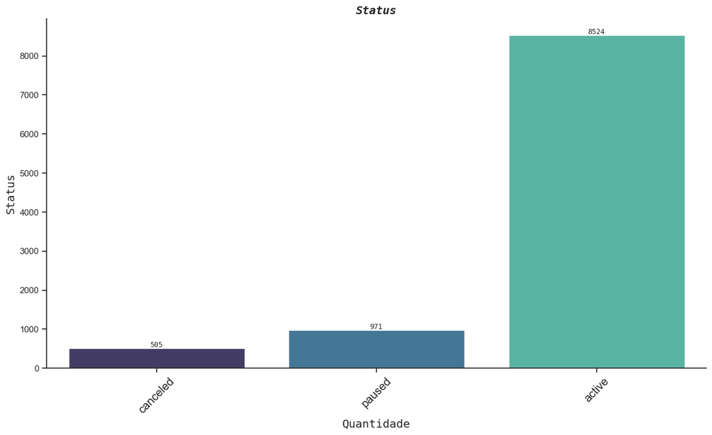

```python
create_count_plot(df, 'status', 'Status', 'Status', 'Quantidade')
```

```python
def create_bar_plot(df: pd.DataFrame, column: str, title: str, x_label: str) -> None:
    _, ax = plt.subplots(figsize=(16, 8))
    df_ = df.groupby(column)['status'].value_counts(normalize=True).rename('prop').reset_index()
    df_.prop = np.round(df_.prop * 100, 2)
    sns.barplot(data=df_, x=column, y='prop', hue='status', ax=ax)
    ax.legend(title="Status")
    for value in ax.containers:
        ax.bar_label(value, label_type='edge', fontsize=9, family='monospace')
    ax.set_xlabel(x_label, fontsize='large', family='monospace')
    ax.set_ylabel('Proporção', fontsize='large', family='monospace')
    ax.set_title(title, fontsize='large', fontweight='bold', style='italic', family='monospace')
```

A partir do marketing vamos analisar a proporção de clientes ativos, pausados e cancelados.

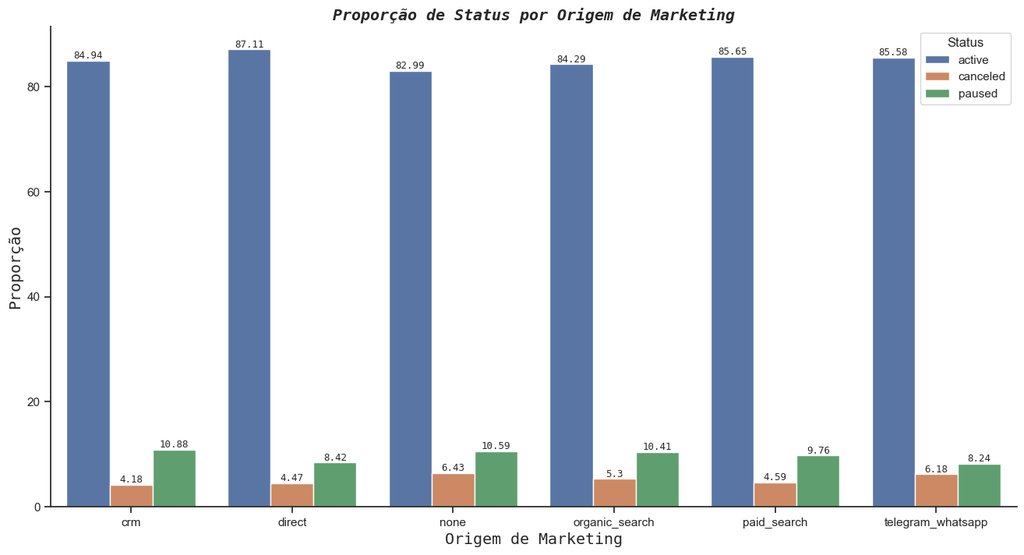

```python
create_bar_plot(df, 'marketing_source', 'Proporção de Status por Origem de Marketing', 'Origem de Marketing')
plt.show()
```

Analogamente ao caso anterior, agora observaremos a proporção de clientes ativos, pausados e cancelados por estado, infelizmente a visualização foi comprometida pela quantidade de itens.

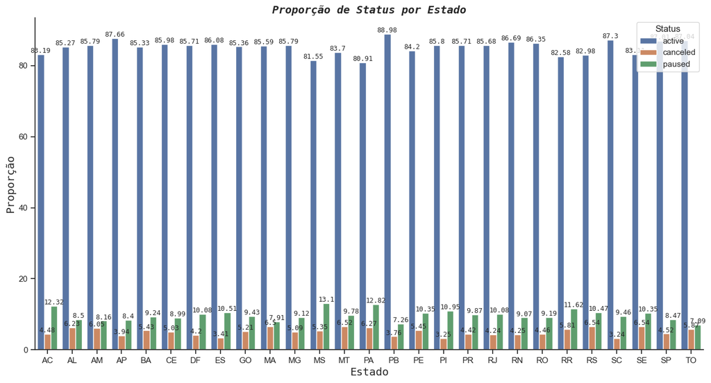

```python
create_bar_plot(df, 'state', 'Proporção de Status por Estado', 'Estado')
plt.show()
```

```python
def create_bar_plot(df=df, y: str = '', title: str = '', xlabel: str = '', ylabel: str = '', rot=45):
    _, ax = plt.subplots(figsize=(15, 8))
    df = df.sort_values(by=y, ascending=True)[y]
    sns.barplot(data=df, x=df.index, y=df.values, palette=PALETTE)
    for value in ax.containers:
        ax.bar_label(value, label_type='edge', fontsize=9, family='monospace')
    ax.set_xlabel(ylabel, fontsize='large', family='monospace')
    ax.set_ylabel(xlabel, fontsize='large', family='monospace')
    ax.set_title(title, fontsize='large', fontweight='bold', style='italic', family='monospace')
    ax.set_xticks(np.arange(df.index.shape[0]))
    ax.set_xticklabels(df.index, rotation=rot)
    plt.show()
```

Como o foco do case é a análise de churn, vamos analisar a proporção de taxa de churn por meio de marketing.

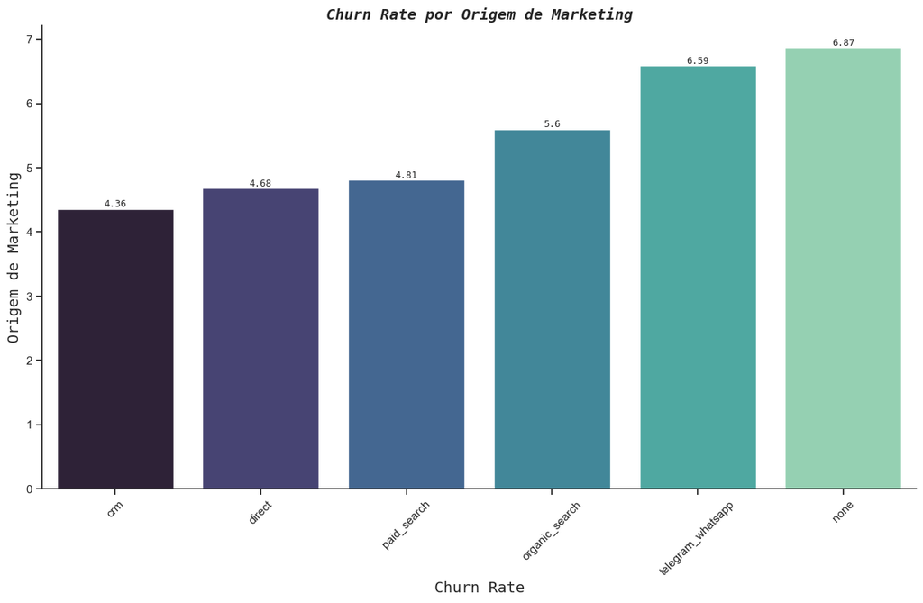

```python
df_grouped = calculate_churn_rate(df, 'created_at', 'marketing_source')
create_bar_plot(df_grouped, y='churn_rate', title='Churn Rate por Origem de Marketing', xlabel='Origem de Marketing', ylabel='Churn Rate')
```

Desta vez a análise será feita por estado.

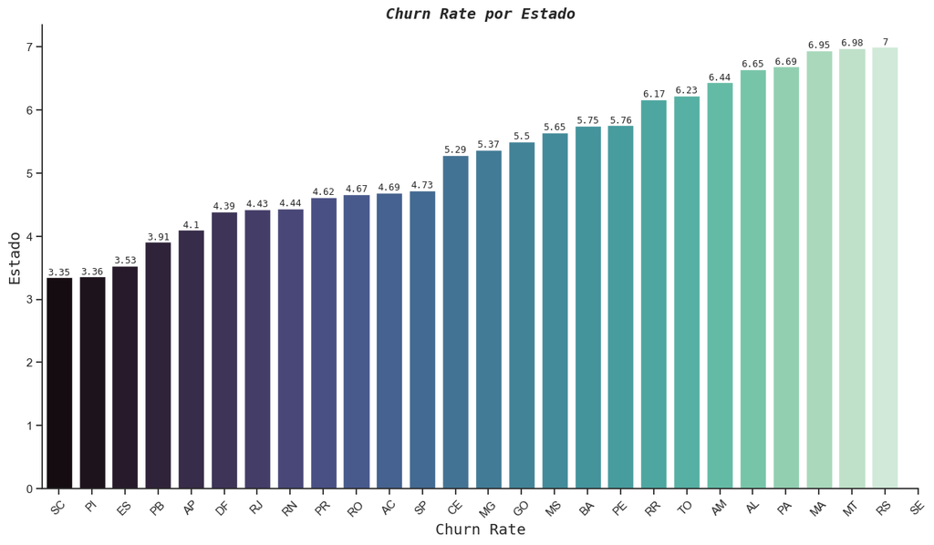

```python
df_grouped = calculate_churn_rate(df, 'created_at', 'state')
create_bar_plot(df_grouped, y='churn_rate', title='Churn Rate por Estado', xlabel='Estado', ylabel='Churn Rate')
```

### Análise de distribuição com histogramas

```python
def create_histogram(df: pd.DataFrame, column: str, title: str, bins: int) -> None:
    _, ax = plt.subplots(figsize=(20, 8))
    sns.histplot(data=df, x=column, hue='status', bins=bins, kde=True, alpha=.75)
    ax.legend(title="Status", loc="upper right", labels=["Paused", "Canceled", "Active"])
    for value in ax.containers:
        ax.bar_label(value, label_type='edge', fontsize=9, family='monospace')
    ax.set_xlabel(None)
    ax.set_ylabel('Contagem', fontsize='large', family='monospace')
    ax.set_title(title, fontsize='large', fontweight='bold', style='italic', family='monospace')
```

Análise da distribuição dos casos de cancelamento pelos anos (considerando o ano de criação da conta).

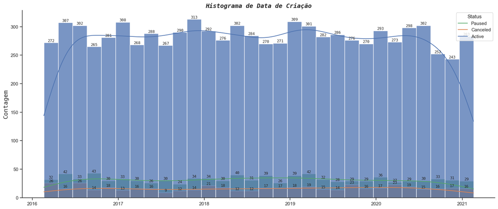

```python
create_histogram(df, 'created_at', 'Histograma de Data de Criação', 30)
plt.show()
```

Análise da distribuição dos casos de cancelamento pela quantidade de itens comprados (vemos que se comporta exatamente como uma distribuição normal).

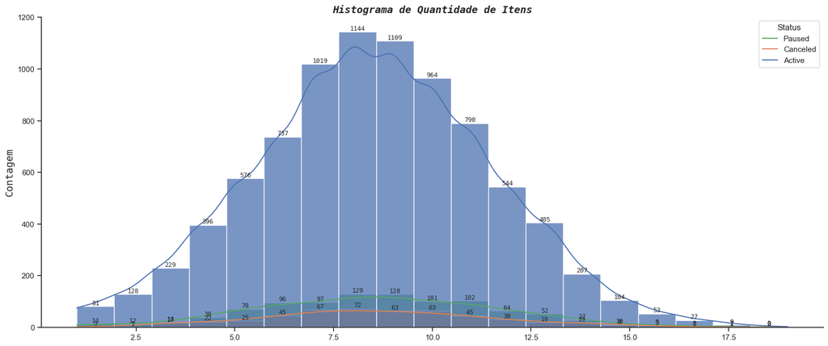

```python
create_histogram(df, 'items_quantity', 'Histograma de Quantidade de Itens', 19)
plt.show()
```

Análise da distribuição dos casos de cancelamento pelo preço médio dos tickets (vemos que se comporta exatamente como uma distribuição normal).

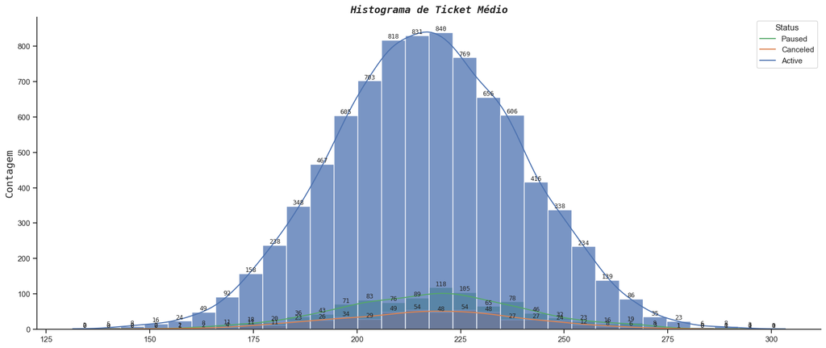

```python
create_histogram(df, 'average_ticket', 'Histograma de Ticket Médio', 30)
plt.show()
```

Análise do histograma pela receita total gasta, desta vez vemos que a distribuição não se comporta como uma normal.

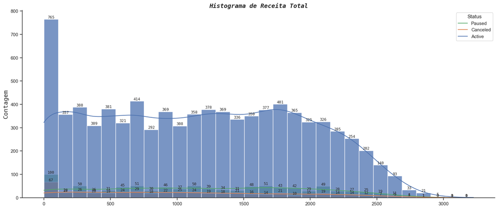

```python
create_histogram(df, 'all_revenue', 'Histograma de Receita Total', 30)
plt.show()
```

Análise do histograma por total de pedidos, vemos que se comporta de maneira constante.

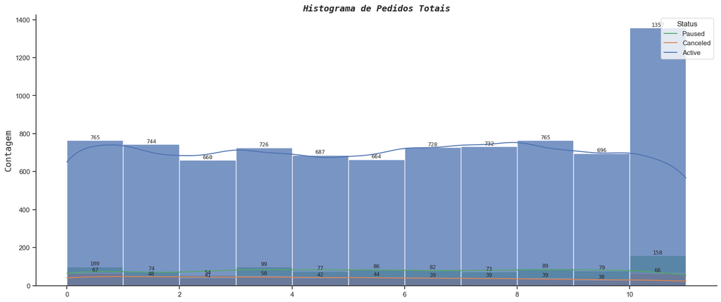

```python
create_histogram(df, 'all_orders', 'Histograma de Pedidos Totais', 11)
plt.show()
```

Análise do histograma por idade, vemos picos de idades com intervalos predefinidos.

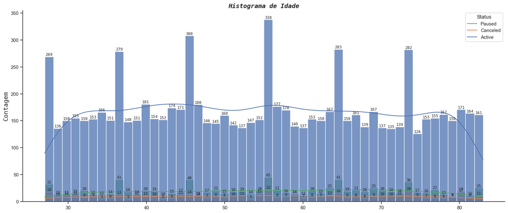

```python
create_histogram(df, 'age', 'Histograma de Idade', 50)
plt.show()
```

Observamos que os clientes costumam comprar de maneira recorrente.

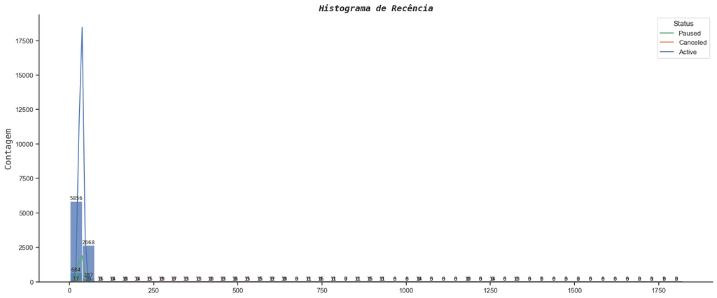

```python
create_histogram(df, 'recency', 'Histograma de Recência', 50)
plt.show()
```

## Análise Temporal

```python
def line_plot_for_temporal(df: pd.DataFrame, column: str, title: str, x_label: str, y_label: str) -> None:
    _, ax = plt.subplots(figsize=(16, 8))
    sns.lineplot(data=df, x=df.index, y=column, marker='o', linewidth=2.5)
    ax.set_xlabel(x_label, fontsize='large', family='monospace')
    ax.set_ylabel(y_label, fontsize='large', family='monospace')
    ax.set_title(title, fontsize='large', fontweight='bold', style='italic', family='monospace')
```

Lembrando que essa análise é baseada no ano de criação da conta.

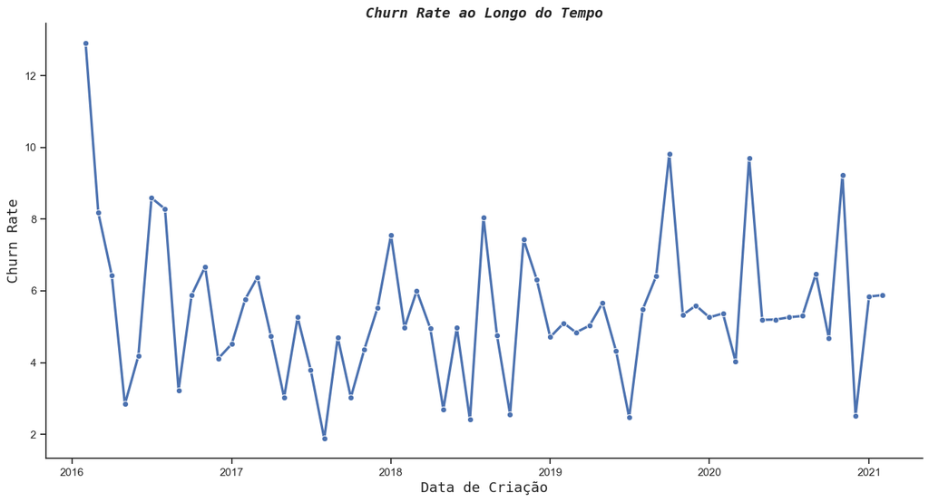

```python
df_temporal = calculate_churn_rate(df, 'created_at')
line_plot_for_temporal(df_temporal, 'churn_rate', 'Churn Rate ao Longo do Tempo', 'Data de Criação', 'Churn Rate')
plt.show()
```

Vemos que a quantidade de churn diminuiu razoavelmente até o seu pico mais baixo (2021/01/01), então cresceu de maneira constante até o pico mais alto (2021/02/01).

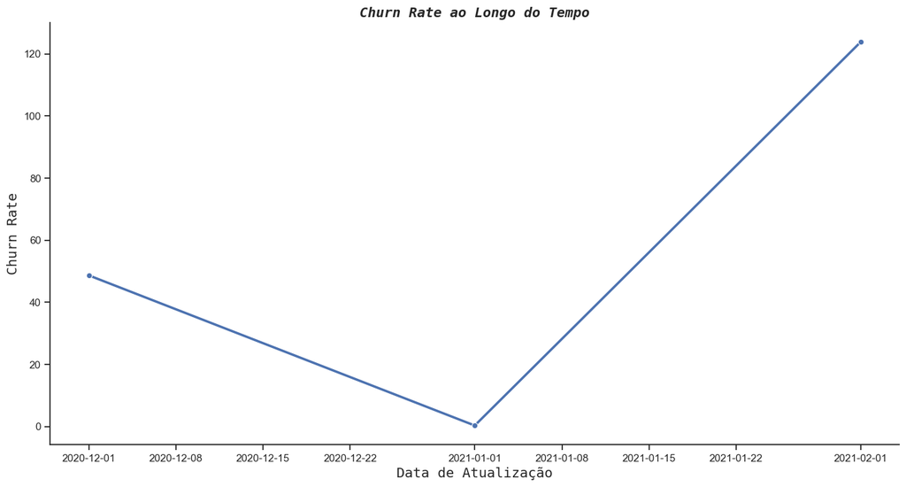

```python
df_temporal = calculate_churn_rate(df, 'updated_at')
line_plot_for_temporal(df_temporal, 'churn_rate', 'Churn Rate ao Longo do Tempo', 'Data de Atualização', 'Churn Rate')
plt.show()
```

Como dito anteriormente nas tabulações, vamos que o tempo de atualização de conta e data de ultima compra estão altamente correlacionados.

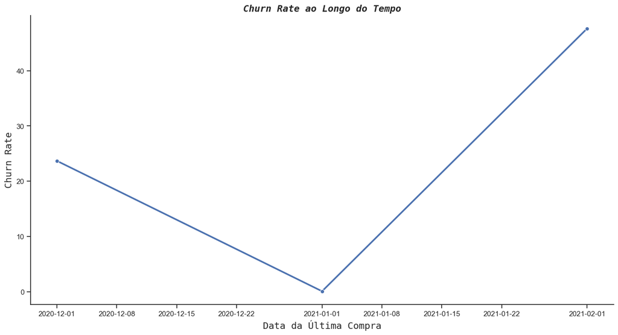

```python
df_temporal = calculate_churn_rate(df, 'last_date_purchase')
line_plot_for_temporal(df_temporal, 'churn_rate', 'Churn Rate ao Longo do Tempo', 'Data da Última Compra', 'Churn Rate')
plt.show()
```

## Conclusão

### Análise dos dados

A importância da análise da taxa de cancelamento é muito grande para uma empresa, pois, é através dela que é possível identificar os clientes que estão insatisfeitos com o serviço prestado e que possuem uma alta probabilidade de cancelar a assinatura.

Conseguimos identificar alguns padrões interessantes que deveriam ser melhor explorados pela empresa, como por exemplo, a alta taxa de cancelamento de clientes provenientes do canal de marketing "None" e "Telegram / Whatsapp".

Além disso alguns estados possuem uma taxa de cancelamento muito alta, como por exemplo, os estados de SE, RS, MT, MA, PA, AL, AM, TO, RR, que possuem uma taxa de cancelamento acima de 6%. Uma possível causa é que 7 dos 9 estados citados fazem parte das regiões Norte e Nordeste.

Além disso podemos observar um padrão da taxa de cancelamento relacionado a épocas do ano, onde os meses referentes ao meio do ano (Maio, Junho e Julho) possuem baixa taxa de cancelamento.

Apesar do canal de marketing Organic Search ser o que mais realiza a captação de clientes, ele possui uma taxa de cancelamento de 5.6%, sendo a terceira maior.

### Sugestões

- Avaliar a realização de pesquisas de satisfação com os clientes para identificar os principais motivos de cancelamento.
- Melhorar a experiência do usuário no site, para que o cliente consiga encontrar os produtos que deseja com mais facilidade.
- Investir em estratégias de marketing para o canal Organic Search, onde possui o maior número de clientes captados, buscando manter esses clientes satisfeitos.
- Identificar os problemas com os clientes captados via Telegram e Whatsapp.
- Um possível problema relacionado aos estados pode ser a logística, onde os produtos podem demorar mais para chegar, ou até mesmo chegar com avarias. Além do custo alto de frete para esses estados.
- Será interessante utilizar uma abordagem temporal para medição/predição de cancelamentos, onde será possível identificar os clientes que estão com uma alta probabilidade de cancelar a assinatura.